# Fertility and Mothers’ Labor-Market Outcomes: Design and Descriptive Diagnostics

Analysis samples · treatment uptake · IV building blocks · overlap and balance

Alexander Unger

03 August 2026

Following Słoczyński, Uysal, and Wooldridge, the application distinguishes the labor-force-participation sample from the positive-income sample. The computational analysis uses one fixed 3,000-observation proportional stratified subsample for each outcome family. The comparison below documents how closely their central IV moments track the corresponding parent samples.

# 1. Samples and Empirical Design

**Instrument:** whether the first two children have the same sex (`samesex`). **Treatment:** having more than two children (`morekids`). **Outcomes:** maternal labor-force participation and maternal log income in dollars. Every conditional diagnostic uses the same six covariates as the main Child analysis: mother’s age, age at first birth, first-child sex, and the three race indicators.

```r
data_candidates <- c("ae98.dta", file.path("child", "ae98.dta"))
data_file <- data_candidates[file.exists(data_candidates)][1]
if (is.na(data_file)) stop("Could not find ae98.dta in the notebook or project directory.")

ae98_raw <- read_dta(data_file)
base_vars <- c("workedm", "morekids", "samesex", "agem", "agefstm",
               "sexk", "sex2nd", "blackm", "hispm", "othracem")
ae98_labor_parent <- ae98_raw %>%
  filter(if_all(all_of(base_vars), ~ !is.na(.x)))
ae98_income_parent <- ae98_labor_parent %>%
  filter(!is.na(incomem), incomem > 0)

sample_moments <- function(df, y, sample, source) {
  data.frame(
    Sample = sample,
    Source = source,
    N = nrow(df),
    `Pr(Z = 1)` = mean(df$samesex),
    `Pr(D = 1)` = mean(df$morekids),
    `First-stage gap` = mean(df$morekids[df$samesex == 1]) -
      mean(df$morekids[df$samesex == 0]),
    `Reduced-form gap` = mean(y[df$samesex == 1]) - mean(y[df$samesex == 0]),
    check.names = FALSE
  )
}

validation_tab <- bind_rows(
  sample_moments(ae98_labor_parent, ae98_labor_parent$workedm,
                 "Work Status", "Parent sample"),
  sample_moments(ae98_labor_sub, ae98_labor_sub$workedm,
                 "Work Status", "Diagnostic subsample"),
  sample_moments(ae98_income_parent, log(ae98_income_parent$incomem),
                 "Maternal Log Income", "Parent sample"),
  sample_moments(ae98_income_sub, ae98_income_sub$lincomem,
                 "Maternal Log Income", "Diagnostic subsample")
)

validation_tab %>%
  mutate(across(where(is.numeric) & !all_of("N"), ~ round(.x, 4))) %>%
  kbl(caption = "Parent samples and fixed diagnostic subsamples",
      align = c("l", "l", "r", "r", "r", "r", "r"), row.names = FALSE) %>%
  kable_styling(bootstrap_options = c("striped", "hover", "condensed"),
                full_width = TRUE, font_size = 13) %>%
  footnote(general = "The subsamples are used for the computational comparison. Parent-sample moments are shown to make the approximation transparent; estimates and uncertainty in the main notebook refer to the selected subsamples unless stated otherwise.")
```

Parent samples and fixed diagnostic subsamples

| Sample | Source | N | Pr(Z = 1) | Pr(D = 1) | First-stage gap | Reduced-form gap |
| --- | --- | --- | --- | --- | --- | --- |
| Work Status | Parent sample | 394840 | 0.5054 | 0.4021 | 0.0595 | -0.0079 |
| Work Status | Diagnostic subsample | 3000 | 0.5050 | 0.4017 | 0.0606 | -0.0073 |
| Maternal Log Income | Parent sample | 220502 | 0.5018 | 0.3493 | 0.0543 | -0.0089 |
| Maternal Log Income | Diagnostic subsample | 3000 | 0.5027 | 0.3477 | 0.0530 | -0.0122 |

Note:  
The subsamples are used for the computational comparison. Parent-sample moments are shown to make the approximation transparent; estimates and uncertainty in the main notebook refer to the selected subsamples unless stated otherwise.

## Covariate Specification and Construction of the Instrument

`samesex` is exactly $1\{\texttt{sexk}=\texttt{sex2nd}\}$. An unrestricted tree learner supplied with both child-sex indicators can therefore reconstruct the instrument and eliminate the residual instrument variation required by DML. Moreover, within $Z=1$, `sex2nd = sexk`, whereas within $Z=0$, `sex2nd = 1 - sexk`. Including both variables in an arm-specific parametric nuisance fit creates exact rank deficiency. The analysis consequently retains `sexk` and omits `sex2nd`. Angrist and Evans report that removing the individual child-sex controls changes their estimates by no more than about two percent. See [Angrist and Evans (1998)](https://www.dpipe.tsukuba.ac.jp/~naito/teaching_web/public_economics_2013_web/Angrist_Evans_AER_1998.pdf).

```r
sex_structure <- function(df, label) {
  constructed_z <- as.integer(df$sexk == df$sex2nd)
  data.frame(
    Sample = label,
    N = nrow(df),
    `Exact construction` = all(df$samesex == constructed_z),
    Mismatches = sum(df$samesex != constructed_z),
    `Pooled correlation` = cor(df$sexk, df$sex2nd),
    `Correlation, Z = 0` = cor(
      df$sexk[df$samesex == 0], df$sex2nd[df$samesex == 0]
    ),
    `Correlation, Z = 1` = cor(
      df$sexk[df$samesex == 1], df$sex2nd[df$samesex == 1]
    ),
    check.names = FALSE
  )
}

sex_structure_tab <- bind_rows(
  sex_structure(ae98_labor_sub, "Work Status"),
  sex_structure(ae98_income_sub, "Maternal Log Income")
)

sex_structure_tab %>%
  mutate(across(contains("correlation"), ~ round(.x, 3))) %>%
  kbl(
    caption = "Construction of the instrument from the child-sex indicators",
    align = c("l", "r", "c", "r", "r", "r", "r")
  ) %>%
  kable_styling(
    bootstrap_options = c("striped", "hover", "condensed"),
    full_width = TRUE, font_size = 12.5
  ) %>%
  footnote(general = paste(
    "Exact construction verifies samesex = 1{sexk = sex2nd} observation by observation.",
    "The pooled correlation can be near zero even though the two indicators are",
    "perfectly related within each instrument arm."
  ))
```

Construction of the instrument from the child-sex indicators

| Sample | N | Exact construction | Mismatches | Pooled correlation | Correlation, Z = 0 | Correlation, Z = 1 |
| --- | --- | --- | --- | --- | --- | --- |
| Work Status | 3000 | TRUE | 0 | 0.010 | -1 | 1 |
| Maternal Log Income | 3000 | TRUE | 0 | 0.005 | -1 | 1 |

Note:  
Exact construction verifies samesex = 1{sexk = sex2nd} observation by observation. The pooled correlation can be near zero even though the two indicators are perfectly related within each instrument arm.

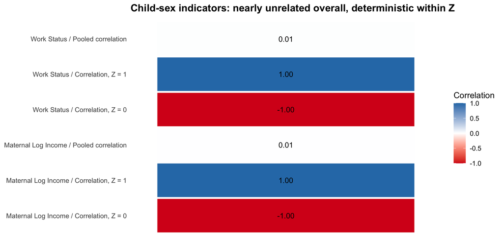

```r
sex_corr_plot <- sex_structure_tab %>%
  select(Sample, `Pooled correlation`, `Correlation, Z = 0`,
         `Correlation, Z = 1`) %>%
  pivot_longer(
    -Sample, names_to = "Panel", values_to = "Correlation"
  ) %>%
  mutate(Panel = paste(Sample, Panel, sep = " / "),
         Pair = "cor(sexk, sex2nd)")

ggplot(sex_corr_plot, aes(x = Pair, y = Panel, fill = Correlation)) +
  geom_tile(colour = "white", linewidth = 1.2) +
  geom_text(aes(label = sprintf("%.2f", Correlation)),
            size = 3.8, colour = "black") +
  scale_fill_gradient2(low = col_z0, mid = "white", high = col_z1,
                       limits = c(-1, 1), name = "Correlation") +
  labs(
    title = "Child-sex indicators: nearly unrelated overall, deterministic within Z",
    x = NULL, y = NULL
  ) +
  theme_minimal(base_size = 12) +
  theme(axis.text.x = element_blank(),
        panel.grid = element_blank(),
        plot.title = element_text(face = "bold"))
```

# 2. Distributions of Z, D, and Y

```r
distribution_tab <- bind_rows(
  data.frame(
    Sample = "Work Status", N = nrow(ae98_labor_sub),
    `Pr(Z = 1)` = mean(ae98_labor_sub$samesex),
    `Pr(D = 1)` = mean(ae98_labor_sub$morekids),
    `Outcome mean` = mean(ae98_labor_sub$workedm),
    `Outcome SD` = sd(ae98_labor_sub$workedm),
    `Outcome P05` = quantile(ae98_labor_sub$workedm, .05),
    `Outcome median` = median(ae98_labor_sub$workedm),
    `Outcome P95` = quantile(ae98_labor_sub$workedm, .95),
    check.names = FALSE
  ),
  data.frame(
    Sample = "Maternal Log Income", N = nrow(ae98_income_sub),
    `Pr(Z = 1)` = mean(ae98_income_sub$samesex),
    `Pr(D = 1)` = mean(ae98_income_sub$morekids),
    `Outcome mean` = mean(ae98_income_sub$lincomem),
    `Outcome SD` = sd(ae98_income_sub$lincomem),
    `Outcome P05` = quantile(ae98_income_sub$lincomem, .05),
    `Outcome median` = median(ae98_income_sub$lincomem),
    `Outcome P95` = quantile(ae98_income_sub$lincomem, .95),
    check.names = FALSE
  )
)

distribution_tab %>%
  mutate(across(where(is.numeric) & !all_of("N"), ~ round(.x, 3))) %>%
  kbl(caption = "Instrument, treatment, and outcome distributions",
      align = c("l", rep("r", ncol(distribution_tab) - 1))) %>%
  kable_styling(bootstrap_options = c("striped","hover","condensed"),
                full_width = TRUE, font_size = 12.5)
```

Instrument, treatment, and outcome distributions

|  | Sample | N | Pr(Z = 1) | Pr(D = 1) | Outcome mean | Outcome SD | Outcome P05 | Outcome median | Outcome P95 |
| --- | --- | --- | --- | --- | --- | --- | --- | --- | --- |
| 5%…1 | Work Status | 3000 | 0.505 | 0.402 | 0.565 | 0.496 | 0.000 | 1.00 | 1.000 |
| 5%…2 | Maternal Log Income | 3000 | 0.503 | 0.348 | 8.933 | 1.260 | 6.394 | 9.26 | 10.422 |

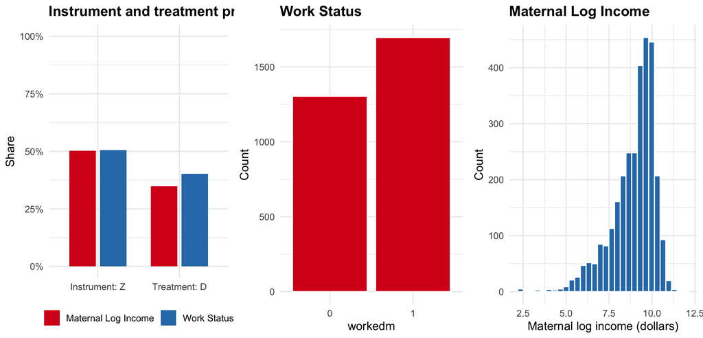

```r
zd_plot_data <- bind_rows(
  data.frame(Sample = "Work Status", Variable = c("Instrument: Z", "Treatment: D"),
             Share = c(mean(ae98_labor_sub$samesex), mean(ae98_labor_sub$morekids))),
  data.frame(Sample = "Maternal Log Income", Variable = c("Instrument: Z", "Treatment: D"),
             Share = c(mean(ae98_income_sub$samesex), mean(ae98_income_sub$morekids)))
)

p_zd <- ggplot(zd_plot_data, aes(x = Variable, y = Share, fill = Sample)) +
  geom_col(position = position_dodge(width = .75), width = .65) +
  scale_fill_manual(values = c("Work Status" = col_z1,
                               "Maternal Log Income" = col_z0)) +
  scale_y_continuous(labels = percent_format(), limits = c(0, 1)) +
  labs(title = "Instrument and treatment prevalence", x = NULL, y = "Share", fill = NULL) +
  theme_minimal(base_size = 12) +
  theme(legend.position = "bottom", plot.title = element_text(face = "bold"))

p_labor <- ggplot(ae98_labor_sub, aes(x = factor(workedm))) +
  geom_bar(fill = col_z0, colour = "white") +
  labs(title = "Work Status", x = "workedm", y = "Count") +
  theme_minimal(base_size = 12) +
  theme(plot.title = element_text(face = "bold"))

p_income <- ggplot(ae98_income_sub, aes(x = lincomem)) +
  geom_histogram(bins = 30, fill = col_z1, colour = "white") +
  labs(title = "Maternal Log Income",
       x = "Maternal log income (dollars)", y = "Count") +
  theme_minimal(base_size = 12) +
  theme(plot.title = element_text(face = "bold"))

grid.arrange(p_zd, p_labor, p_income, ncol = 3)
```

# 3. Instrument–Treatment Composition

```r
first_stage <- function(df) {
  mean(df$morekids[df$samesex == 1]) - mean(df$morekids[df$samesex == 0])
}

reduced_form <- function(df, y) {
  mean(y[df$samesex == 1]) - mean(y[df$samesex == 0])
}

fmt_num <- function(x) {
  ifelse(is.na(x), "--",
         ifelse(abs(x) >= 1000, format(round(x), big.mark = ",", scientific = FALSE),
                sprintf("%.4f", x)))
}

coef_hc1 <- function(model, term) {
  se <- sqrt(diag(vcovHC(model, type = "HC1")))[term]
  est <- coef(model)[term]
  c(estimate = unname(est), se = unname(se), robust_t2 = unname((est / se)^2))
}
```

```r
cell_table <- function(df, label) {
  tab <- table(
    factor(df$samesex, levels = 0:1),
    factor(df$morekids, levels = 0:1)
  )
  p_d_z1 <- mean(df$morekids[df$samesex == 1])
  p_d_z0 <- mean(df$morekids[df$samesex == 0])

  data.frame(
    Sample = label,
    `n(Z=0,D=0)` = unname(tab["0", "0"]),
    `n(Z=0,D=1)` = unname(tab["0", "1"]),
    `n(Z=1,D=0)` = unname(tab["1", "0"]),
    `n(Z=1,D=1)` = unname(tab["1", "1"]),
    `Pr(D=1|Z=1)` = p_d_z1,
    `Pr(D=1|Z=0)` = p_d_z0,
    `Unadjusted gap` = p_d_z1 - p_d_z0,
    check.names = FALSE
  )
}

zd_cells <- bind_rows(
  cell_table(ae98_labor_sub, "Work Status"),
  cell_table(ae98_income_sub, "Maternal Log Income")
)

zd_cells %>%
  mutate(across(starts_with("Pr(") | all_of("Unadjusted gap"), ~ round(.x, 4))) %>%
  kbl(
    caption = "Instrument–treatment cells and unconditional treatment-rate contrasts",
    align = c("l", rep("r", 7))
  ) %>%
  kable_styling(
    bootstrap_options = c("striped", "hover", "condensed"),
    full_width = TRUE, font_size = 12.5
  ) %>%
  add_header_above(c(
    " " = 1, "Cell counts" = 4,
    "Conditional treatment rates" = 2, "Contrast" = 1
  )) %>%
  column_spec(8, bold = TRUE, color = "#2c7bb6") %>%
  footnote(general = paste(
    "Z = samesex and D = morekids. The unadjusted gap is",
    "Pr(D=1|Z=1) - Pr(D=1|Z=0). A principal-strata interpretation",
    "additionally requires the relevant IV assumptions."
  ))
```

Instrument–treatment cells and unconditional treatment-rate contrasts

| Sample | Cell counts n(Z=0,D=0) | Cell counts n(Z=0,D=1) | Cell counts n(Z=1,D=0) | Cell counts n(Z=1,D=1) | Conditional treatment rates Pr(D=1\|Z=1) | Conditional treatment rates Pr(D=1\|Z=0) | Contrast Unadjusted gap |
| --- | --- | --- | --- | --- | --- | --- | --- |
| Work Status | 934 | 551 | 861 | 654 | 0.4317 | 0.371 | 0.0606 |
| Maternal Log Income | 1013 | 479 | 944 | 564 | 0.3740 | 0.321 | 0.0530 |

Note:  
Z = samesex and D = morekids. The unadjusted gap is Pr(D=1|Z=1) - Pr(D=1|Z=0). A principal-strata interpretation additionally requires the relevant IV assumptions.

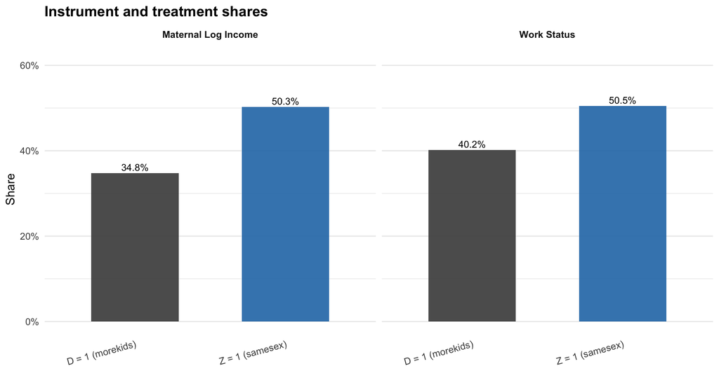

```r
zd_share_plot <- bind_rows(
  ae98_labor_sub %>%
    summarise(Sample = "Work Status",
              `Z = 1 (samesex)` = mean(samesex),
              `D = 1 (morekids)` = mean(morekids)),
  ae98_income_sub %>%
    summarise(Sample = "Maternal Log Income",
              `Z = 1 (samesex)` = mean(samesex),
              `D = 1 (morekids)` = mean(morekids))
) %>%
  pivot_longer(-Sample, names_to = "Measure", values_to = "Share")

ggplot(zd_share_plot, aes(x = Measure, y = Share, fill = Measure)) +
  geom_col(width = 0.58, alpha = 0.92) +
  geom_text(aes(label = percent(Share, accuracy = 0.1)),
            vjust = -0.35, size = 3.4) +
  facet_wrap(~ Sample) +
  scale_fill_manual(values = c("Z = 1 (samesex)" = col_z1,
                               "D = 1 (morekids)" = col_grey)) +
  scale_y_continuous(labels = percent_format(accuracy = 1),
                     limits = c(0, .62)) +
  labs(title = "Instrument and treatment shares",
       x = NULL, y = "Share", fill = NULL) +
  theme_minimal(base_size = 12) +
  theme(legend.position = "none",
        panel.grid.major.x = element_blank(),
        axis.text.x = element_text(angle = 15, hjust = 1),
        strip.text = element_text(face = "bold"),
        plot.title = element_text(face = "bold"))
```

# 4. First Stage, Reduced Form, and Linear-IV Benchmark

The unadjusted differences summarize the two instrument groups. The adjusted results use the same covariates as the main child analysis.

```r
iv_summary <- function(df, y, label, outcome_label) {
  d_z1 <- mean(df$morekids[df$samesex == 1])
  d_z0 <- mean(df$morekids[df$samesex == 0])
  y_z1 <- mean(y[df$samesex == 1])
  y_z0 <- mean(y[df$samesex == 0])
  raw_fs <- d_z1 - d_z0
  raw_rf <- y_z1 - y_z0

  df$.y <- y
  fs_raw <- coef_hc1(lm(morekids ~ samesex, data = df), "samesex")
  fs_adj <- coef_hc1(lm(as.formula(paste("morekids ~ samesex +", RHS)), data = df), "samesex")
  rf_adj <- coef_hc1(lm(as.formula(paste(".y ~ samesex +", RHS)), data = df), "samesex")

  data.frame(
    Sample = label,
    Outcome = outcome_label,
    N = nrow(df),
    `Pr(Z = 1)` = mean(df$samesex),
    `Pr(D = 1)` = mean(df$morekids),
    `Raw first stage` = raw_fs,
    `Raw first-stage SE` = unname(fs_raw["se"]),
    `Raw robust t²` = unname(fs_raw["robust_t2"]),
    `Adj. first stage` = unname(fs_adj["estimate"]),
    `Adj. first-stage SE` = unname(fs_adj["se"]),
    `Adj. robust t²` = unname(fs_adj["robust_t2"]),
    `Raw reduced form` = raw_rf,
    `Adj. reduced form` = unname(rf_adj["estimate"]),
    `Adj. reduced-form SE` = unname(rf_adj["se"]),
    `Raw Wald` = raw_rf / raw_fs,
    `Adj. Wald` = unname(rf_adj["estimate"] / fs_adj["estimate"]),
    check.names = FALSE
  )
}

iv_summary_tab <- bind_rows(
  iv_summary(ae98_labor_sub, ae98_labor_sub$workedm,
             "Work Status", "workedm"),
  iv_summary(ae98_income_sub, ae98_income_sub$lincomem,
             "Maternal Log Income", "maternal log income")
)

first_stage_tab <- bind_rows(
  iv_summary_tab %>% transmute(
    Sample, Specification = "Unadjusted",
    `First stage` = `Raw first stage`,
    `Robust SE` = `Raw first-stage SE`,
    `Robust t²` = `Raw robust t²`
  ),
  iv_summary_tab %>% transmute(
    Sample, Specification = "Adjusted",
    `First stage` = `Adj. first stage`,
    `Robust SE` = `Adj. first-stage SE`,
    `Robust t²` = `Adj. robust t²`
  )
) %>%
  arrange(factor(Sample, levels = c("Work Status", "Maternal Log Income")),
          factor(Specification, levels = c("Unadjusted", "Adjusted")))

linear_iv_tab <- bind_rows(
  iv_summary_tab %>% transmute(
    Sample, Specification = "Unadjusted",
    `First stage` = `Raw first stage`,
    `Reduced form` = `Raw reduced form`, Wald = `Raw Wald`
  ),
  iv_summary_tab %>% transmute(
    Sample, Specification = "Adjusted",
    `First stage` = `Adj. first stage`,
    `Reduced form` = `Adj. reduced form`, Wald = `Adj. Wald`
  )
) %>%
  arrange(factor(Sample, levels = c("Work Status", "Maternal Log Income")),
          factor(Specification, levels = c("Unadjusted", "Adjusted")))

first_stage_tab %>%
  mutate(across(where(is.numeric), fmt_num)) %>%
  kbl(
    caption = "First-stage strength in the selected subsamples",
    align = c("l", "l", "r", "r", "r"), row.names = FALSE
  ) %>%
  kable_styling(
    bootstrap_options = c("striped", "hover", "condensed"),
    full_width = FALSE, font_size = 13
  ) %>%
  footnote(general = paste(
    "Robust t² is the squared HC1 t-statistic for samesex.",
    "Adjusted regressions use the common six-covariate specification."
  ))
```

First-stage strength in the selected subsamples

| Sample | Specification | First stage | Robust SE | Robust t² |
| --- | --- | --- | --- | --- |
| Work Status | Unadjusted | 0.0606 | 0.0179 | 11.5162 |
| Work Status | Adjusted | 0.0648 | 0.0172 | 14.1148 |
| Maternal Log Income | Unadjusted | 0.0530 | 0.0174 | 9.3010 |
| Maternal Log Income | Adjusted | 0.0596 | 0.0166 | 12.8954 |

Note:  
Robust t² is the squared HC1 t-statistic for samesex. Adjusted regressions use the common six-covariate specification.

```r
linear_iv_tab %>%
  mutate(across(where(is.numeric), fmt_num)) %>%
  kbl(
    caption = "Linear-IV building blocks in the selected subsamples",
    align = c("l", "l", "r", "r", "r"), row.names = FALSE
  ) %>%
  kable_styling(
    bootstrap_options = c("striped", "hover", "condensed"),
    full_width = FALSE, font_size = 13
  ) %>%
  column_spec(5, bold = TRUE) %>%
  footnote(general = paste(
    "The unadjusted entries are instrument-group mean differences.",
    "With the same linear controls in both equations, the adjusted ratio",
    "equals the just-identified linear-IV coefficient."
  ))
```

Linear-IV building blocks in the selected subsamples

| Sample | Specification | First stage | Reduced form | Wald |
| --- | --- | --- | --- | --- |
| Work Status | Unadjusted | 0.0606 | -0.0073 | -0.1205 |
| Work Status | Adjusted | 0.0648 | -0.0061 | -0.0946 |
| Maternal Log Income | Unadjusted | 0.0530 | -0.0122 | -0.2300 |
| Maternal Log Income | Adjusted | 0.0596 | -0.0109 | -0.1822 |

Note:  
The unadjusted entries are instrument-group mean differences. With the same linear controls in both equations, the adjusted ratio equals the just-identified linear-IV coefficient.

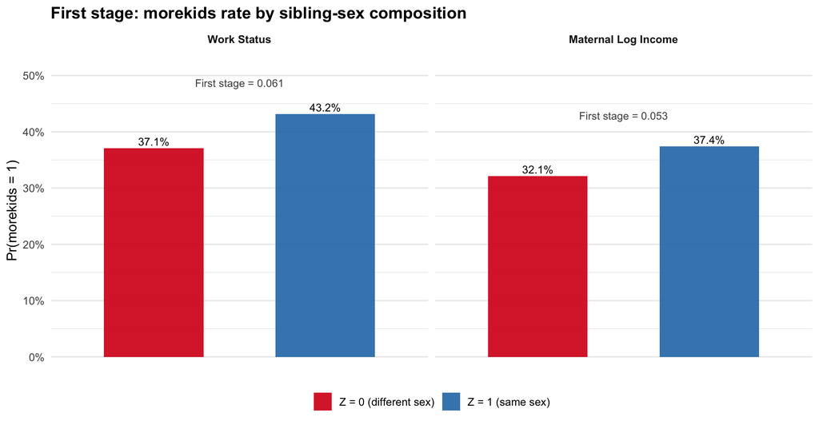

```r
first_stage_plot <- bind_rows(
  ae98_labor_sub %>%
    group_by(samesex) %>%
    summarise(Sample = "Work Status", Rate = mean(morekids), .groups = "drop"),
  ae98_income_sub %>%
    group_by(samesex) %>%
    summarise(Sample = "Maternal Log Income", Rate = mean(morekids), .groups = "drop")
) %>%
  mutate(
    Sample = factor(Sample, levels = c("Work Status", "Maternal Log Income")),
    `Z group` = ifelse(samesex == 1, "Z = 1 (same sex)", "Z = 0 (different sex)")
  )

first_stage_labels <- first_stage_plot %>%
  select(Sample, samesex, Rate) %>%
  pivot_wider(names_from = samesex, values_from = Rate, names_prefix = "z") %>%
  mutate(Gap = z1 - z0,
         Label = paste0("First stage = ", sprintf("%.3f", Gap)))

ggplot(first_stage_plot, aes(x = `Z group`, y = Rate, fill = `Z group`)) +
  geom_col(width = 0.58, alpha = 0.92) +
  geom_text(aes(label = percent(Rate, accuracy = 0.1)),
            vjust = -0.35, size = 3.4) +
  geom_text(data = first_stage_labels,
            aes(x = 1.5, y = pmax(z0, z1) + .055, label = Label),
            inherit.aes = FALSE, size = 3.3, colour = col_grey) +
  facet_wrap(~ Sample) +
  scale_fill_manual(values = c("Z = 1 (same sex)" = col_z1,
                               "Z = 0 (different sex)" = col_z0)) +
  scale_y_continuous(labels = percent_format(accuracy = 1),
                     limits = c(0, .52)) +
  labs(title = "First stage: morekids rate by sibling-sex composition",
       x = NULL, y = "Pr(morekids = 1)", fill = NULL) +
  theme_minimal(base_size = 12) +
  theme(legend.position = "bottom",
        panel.grid.major.x = element_blank(),
        axis.text.x = element_blank(),
        strip.text = element_text(face = "bold"),
        plot.title = element_text(face = "bold"))
```

```r
outcome_by_z <- bind_rows(
  ae98_labor_sub %>%
    group_by(samesex) %>%
    summarise(
      Sample = "Work Status",
      Outcome = "workedm",
      N = n(),
      Mean = mean(workedm),
      SD = sd(workedm),
      .groups = "drop"
    ),
  ae98_income_sub %>%
    group_by(samesex) %>%
    summarise(
      Sample = "Maternal Log Income",
      Outcome = "maternal log income",
      N = n(),
      Mean = mean(lincomem),
      SD = sd(lincomem),
      .groups = "drop"
    )
) %>%
  mutate(`Z group` = ifelse(samesex == 1, "Z = 1 (same sex)", "Z = 0 (different sex)")) %>%
  select(Sample, Outcome, `Z group`, N, Mean, SD)

outcome_by_z %>%
  select(-Outcome) %>%
  mutate(across(c(Mean, SD), ~ round(.x, 4))) %>%
  kbl(caption = "Outcome distribution by instrument status",
      align = c("l", "l", "r", "r", "r")) %>%
  kable_styling(bootstrap_options = c("striped", "hover", "condensed"),
                full_width = TRUE, font_size = 13) %>%
  footnote(general = "The mean differences across Z are the raw reduced forms summarized above.")
```

Outcome distribution by instrument status

| Sample | Z group | N | Mean | SD |
| --- | --- | --- | --- | --- |
| Work Status | Z = 0 (different sex) | 1485 | 0.5690 | 0.4954 |
| Work Status | Z = 1 (same sex) | 1515 | 0.5617 | 0.4963 |
| Maternal Log Income | Z = 0 (different sex) | 1492 | 8.9395 | 1.2516 |
| Maternal Log Income | Z = 1 (same sex) | 1508 | 8.9274 | 1.2679 |

Note:  
The mean differences across Z are the raw reduced forms summarized above.

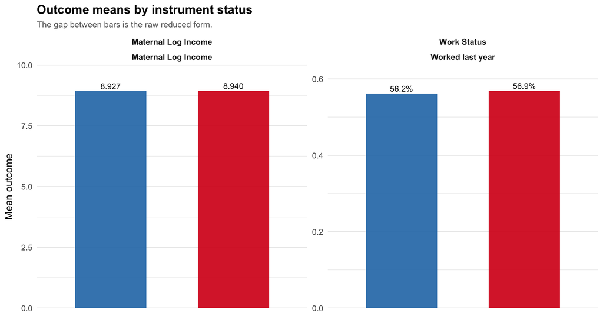

```r
outcome_mean_plot <- outcome_by_z %>%
  mutate(
    `Z group` = factor(`Z group`,
                       levels = c("Z = 1 (same sex)", "Z = 0 (different sex)")),
    Outcome = dplyr::recode(Outcome,
                            workedm = "Worked last year",
                            `maternal log income` = "Maternal Log Income")
  )

ggplot(outcome_mean_plot, aes(x = `Z group`, y = Mean, fill = `Z group`)) +
  geom_col(width = 0.58, alpha = 0.92) +
  geom_text(aes(label = ifelse(Outcome == "Worked last year",
                               percent(Mean, accuracy = 0.1),
                               sprintf("%.3f", Mean))),
            vjust = -0.35, size = 3.4) +
  facet_wrap(~ Sample + Outcome, scales = "free_y") +
  scale_fill_manual(values = c("Z = 1 (same sex)" = col_z1,
                               "Z = 0 (different sex)" = col_z0)) +
  scale_y_continuous(expand = expansion(mult = c(0, .12))) +
  labs(title = "Outcome means by instrument status",
       subtitle = "The gap between bars is the raw reduced form.",
       x = NULL, y = "Mean outcome", fill = NULL) +
  theme_minimal(base_size = 12) +
  theme(legend.position = "none",
        panel.grid.major.x = element_blank(),
        axis.text.x = element_blank(),
        strip.text = element_text(face = "bold"),
        plot.title = element_text(face = "bold"),
        plot.subtitle = element_text(colour = "grey40", size = 10))
```

# 5. Propensity-Score Overlap

These diagnostics describe observed support and covariate composition. The additive logit uses the same six covariates as every estimator in the main analysis.

```r
fit_pscore <- function(df) {
  fit <- glm(as.formula(paste("samesex ~", RHS)), data = df, family = binomial())
  as.numeric(fitted(fit))
}

ps_summary <- function(df, label) {
  p <- fit_pscore(df)
  z <- df$samesex
  data.frame(
    Sample = label,
    Min = min(p),
    P05 = quantile(p, .05, names = FALSE),
    P25 = quantile(p, .25, names = FALSE),
    Mean = mean(p),
    P75 = quantile(p, .75, names = FALSE),
    P95 = quantile(p, .95, names = FALSE),
    Max = max(p),
    SD = sd(p),
    `Max, Z=0` = max(p[z == 0]),
    `N(Z=0, p>.90)` = sum(z == 0 & p > .90),
    `Min, Z=1` = min(p[z == 1]),
    `N(Z=1, p<.10)` = sum(z == 1 & p < .10),
    check.names = FALSE
  )
}

ps_tab <- bind_rows(
  ps_summary(ae98_labor_sub, "Work Status"),
  ps_summary(ae98_income_sub, "Maternal Log Income")
)

continuous_cols <- c(
  "Min", "P05", "P25", "Mean", "P75", "P95", "Max", "SD",
  "Max, Z=0", "Min, Z=1"
)

ps_tab %>%
  mutate(across(all_of(continuous_cols), ~ round(.x, 4))) %>%
  kbl(caption = "Propensity-score overlap for Z = samesex",
      align = c("l", rep("r", ncol(ps_tab) - 1))) %>%
  kable_styling(bootstrap_options = c("striped", "hover", "condensed"),
                full_width = TRUE, font_size = 12.5) %>%
  footnote(general = paste(
    "The group-specific columns target the relevant inverse-propensity tails:",
    "high fitted probabilities among Z=0 observations and low fitted",
    "probabilities among Z=1 observations."
  ))
```

Propensity-score overlap for Z = samesex

| Sample | Min | P05 | P25 | Mean | P75 | P95 | Max | SD | Max, Z=0 | N(Z=0, p>.90) | Min, Z=1 | N(Z=1, p<.10) |
| --- | --- | --- | --- | --- | --- | --- | --- | --- | --- | --- | --- | --- |
| Work Status | 0.4494 | 0.4856 | 0.4951 | 0.5050 | 0.5138 | 0.5306 | 0.5530 | 0.0138 | 0.5530 | 0 | 0.4566 | 0 |
| Maternal Log Income | 0.4644 | 0.4793 | 0.4912 | 0.5027 | 0.5126 | 0.5313 | 0.5665 | 0.0159 | 0.5588 | 0 | 0.4657 | 0 |

Note:  
The group-specific columns target the relevant inverse-propensity tails: high fitted probabilities among Z=0 observations and low fitted probabilities among Z=1 observations.

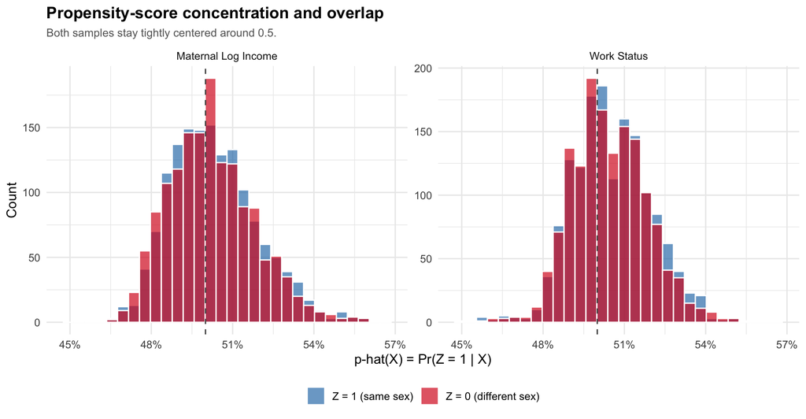

```r
ps_plot_df <- bind_rows(
  ae98_labor_sub %>%
    mutate(Sample = "Work Status", p_hat = fit_pscore(ae98_labor_sub)),
  ae98_income_sub %>%
    mutate(Sample = "Maternal Log Income", p_hat = fit_pscore(ae98_income_sub))
) %>%
  mutate(`Z group` = factor(ifelse(samesex == 1, "Z = 1 (same sex)", "Z = 0 (different sex)"),
                            levels = c("Z = 1 (same sex)", "Z = 0 (different sex)")))

ggplot(ps_plot_df, aes(x = p_hat, fill = `Z group`)) +
  geom_histogram(bins = 30, alpha = 0.68, colour = "white", position = "identity") +
  geom_vline(xintercept = .5, linetype = "dashed", colour = col_grey) +
  facet_wrap(~ Sample, scales = "free_y") +
  scale_fill_manual(values = c("Z = 1 (same sex)" = col_z1,
                               "Z = 0 (different sex)" = col_z0)) +
  scale_x_continuous(labels = percent_format(accuracy = 1)) +
  labs(title = "Propensity-score concentration and overlap",
       subtitle = "Both samples stay tightly centered around 0.5.",
       x = "p-hat(X) = Pr(Z = 1 | X)", y = "Count", fill = NULL) +
  theme_minimal(base_size = 12) +
  theme(legend.position = "bottom",
        plot.title = element_text(face = "bold"),
        plot.subtitle = element_text(colour = "grey40", size = 10))
```